# Project-5

Hannes Gubler

21 May, 2023

# 1 Introduction

Global warming has been a big topic of discussion in the recent years, presenting a difficult challenge that humanity must address. Forecasting future scenarios is an important step towards addressing this challenge, as it allows us to adapt our current behavior and take appropriate steps to reduce global warming.

In this report we use time series analysis to produce short term forecasts of the temperature development. Furthermore we try to determine the form of global warming (more specifically, we will compare the hypotheses of linear, quadratic or exponential growth). In the first part of the report we model the temperature development using the SARIMA method, therefore we dedicate this part to figure out appropriate parameters for this method. Once we have the SARIMA model, we use it for forecasts of global warming as well as a comparison of different scenarios.

# 2 Data Exploration

The data consists of monthly temperature anomalies from 1880 to 2022. In ecology, anomalies are defined as departures from a reference value which, in our case, (probably) corresponds to monthly averages from some earlier time point up to 1960 (where significant increase in temperature is visible due to the industrialization). The temperature from which the anomalies are calculated is a global average.

As a first exploratory tool, we look at the plot of the time series in Figure (2.1).

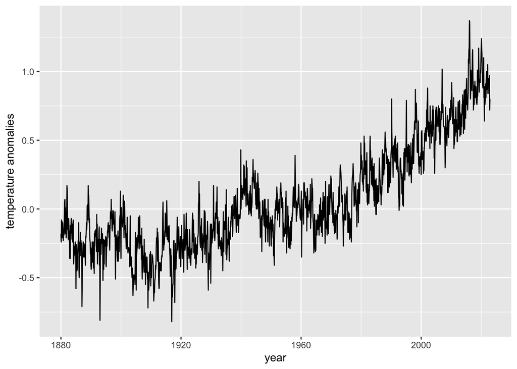

Figure 2.1: Time series of temperature anomalies from 1880 to 2022.

We see a clear upwards trend in our time series, starting from around 1950 up to today. We therefore base our analysis on the time frame from 1950 to 2022 by only selecting the temperature data starting from 1950. Furthermore we do not observe a clear sign of seasonality (a repeating yearly pattern of the time series).

# 3 Time Series SARIMA Model

In this section we try to find an appropriate model to describe the time series from Figure (2.1).

## 3.1 Theoretical Preliminaries

A time series is defined as a stochastic process $(X_t, t \in T)$, where in our case we have $T \subset \mathbb{Z}$ and $(X_t)$ is serially correlated. One important property to model a time series is (weakly) stationarity, which is defined by the following properties.

1. $\mathbb{E}|X_t|^2 < \infty$
2. $\mathbb{E}[X_t] = \mu \quad \forall t \in T$
3. $\text{cov}(X_t,X_s) = \text{cov}(X_{t+h}, X_{s+h}) \quad \forall t,s,h$ such that $t,s,t+h,s+h \in T$

Even tough it is impossible to prove stationarity in practice, we can find evidence against it. The major evidences against stationarity are

- a trend
- seasonality
- non-constant variance
- structural changes in the mean or in the dependency.

If non constant variance is present, a transformation of the data ican be applied (e.g. log transformation).

To deal with a trend and/or seasonality, we decompose our time series, that is $X_t = T_t + S_t + Y_t$ where $T_t$ denotes the trend component, $S_t$ denotes the seasonal component and $Y_t$ denotes the stationary remainder. Then we can apply (seasonal) differencing to the time series $(X_t)$, that is

- In the case where a trend is present, $X_t = T_t + Y_t$ with $T_t \approx T_{t-1}$: $X_t - X_{t-1}$ is approximately stationary (differencing).
- In the case where seasonality is present, $X_t = S_t + Y_t$ with $S_t \approx S_{t-s}$: $X_t - X_{t-s}$ is approximately stationary (seasonal differencing).

Note that by differencing $k$-times, any polynomial trend of degree $k$ can be reduced to a single drift. Furthermore, seasonal differencing can take care of a trend in some cases.

We define a time series $(Z_t, t \in \mathbb{Z})$ as *white noise* if it is stationary, $\mathbb{E}[Z_t]=0$ $\forall t$ and $\text{cov}(X_t, X_{t+h}) = 0$ $\forall h \neq 0$. From now on $(Z_t, t \in \mathbb{Z})$ will always denote white noise.

Our methods used in the following sections are a combination of (seasonal) differencing with the processes MA$(q)$ and AR$(p)$, where we define the latter ones as follows.

- $(X_t, t\in \mathbb{Z})$ is a moving average of order q, denoted by MA$(q)$, if
  $$X_t = Z_t + \theta_1 Z_{t-1} + ... + \theta_q Z_{t-q }$$
- $(X_t, t\in \mathbb{Z})$ is an autoregressive process of order p, denoted by AR$(p)$, if
  $$X_t = Z_t + \phi_1 X_{t-1} + ... + \phi_p X_{t-p}$$

So an AR$(p)$ process can be interpreted as a weighted average of the last $p$ observations plus some white noise. A MA$(q)$ process can be interpreted as a weighted average of the last $q$ noise observations, so its based on the error that the process was not able to predict. An example for an MA$(q)$ process could be the procedure of designing a recipe, where the amount of an ingredient depends on the amount that was missing/too much in the last try.

We denote the combination of an AR$(p)$ and MA$(q)$ process as ARMA$(p,q)$. If we include differencing $d$ times, we denote the model by ARIMA$(p,d,q)$. Then, a SARIMA model is, roughly speaking, an ARIMA$(p,d,q)$ process taking into account seasonality. There are a total of 6 hyperparameters to define in a SARIMA model, denoted by SARIMA$(p,d,q,P,D,Q)$ where we use

- $p$ for the order of the AR component.
- $d$ for the number of differencing.
- $q$ for the order of the MA component.
- $P$ for the order of the AR component on a seasonal level (AR process on the series $(X_{ts})$), where $s$ is the frequency of the season).
- $D$ for the number of seasonal differencing.
- $Q$ for the order of the MA component on a seasonal level (MA process on the series $(X_{ts})$), where $s$ is the frequency of the season).

Once we select hyperparameters of the SARIMA model, the parameters are estimated by Gaussian MLE. In the following sections, we allow all our SARIMA models to include a drift parameter, which acts like an intercept.

## 3.2 SARIMA Model Building

As we saw in Figure (2.1), there is a clear trend visible. To figure our differencing parameter $d$ we fit two linear models to our data: One with linear dependence on time and one with quadratic dependence on time. In both models we include a factor variable `month` specifying the month of the corresponding observation. We then look at the fits of these regressions and their residuals in Figure (3.1).

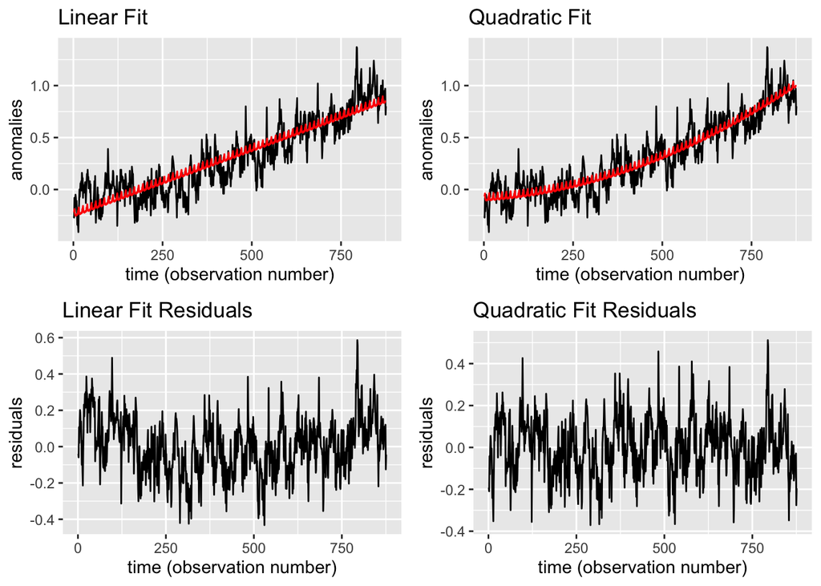

Figure 3.1: Linear models with linear depenency on time (left) and quadratic dependency on time (right) with their residuals for the time series.

Visually the model with quadratic dependency on time seems to be a better approximation of the time series, which can be seen in the fit and especially in the residuals, where we observe a non-linear pattern in the residuals from the linear fit. Looking back at Figure (2.1), also a piecewise linear trend might be plausible, with a knot around 1960. So in our SARIMA model, we will analyze the possibilities of differencing once or twice, to adjust for a linear or quadratic trend.

To determine the parameters $p$ and $q$ we look at the (partial) autocorrelation functions (ACF and PACF) in Figure (3.2). The ACF $\rho(h)$ specifies the correlation between $X_t$ and $X_{t+h}$. The PACF $\alpha(h)$ specifies, roughly speaking, the correlation between $X_t$ and $X_{t+h}$ that remains after the correlation due to all the intermediate observations $X_{t+1},...,X_{t+h-1}$. We have the following characteristics.

Table 3.1: ACF and PACF characteristics for AR, MA, and ARMA models.

| Model | ACF | PACF |
| --- | --- | --- |
| AR(p) | exponential decay | cut-off at lag p |
| MA(q) | cut-off at lag q | exponential decay |
| ARMA(p,q) | mix decay/cut-off | mix decay/cut-off |

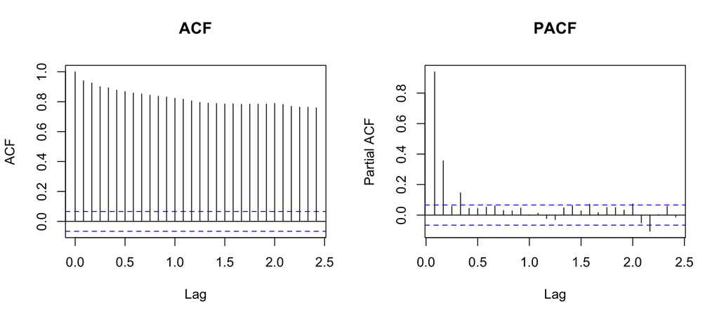

Figure 3.2: ACF and PACF of temperature anomalies time series.

First, note that the ACF plot starts at lag zero (which is always one) while the PACF plot does not. We observe an exponential like decay in the ACF plot and a cut off after two months in the PACF plot, suggesting an ARMA(2,0) model according to Table (3.1). Following Figure (3.1) we chose to analyze the possibilities of differencing once or twice, hence so far we have the possible models ARIMA(2,1,0) and ARIMA(2,2,0).

To complete our SARIMA model we have to account for the seasonality. In Figure (2.1) we did not observe a clear sign of seasonality. The reason for no seasonality could be that the values of our time series are anomalies from a reference value (global average). However, as most of the earths landmass is on the northern hemisphere, there still may be a summer/winter difference in the temperature anomalies and therefore seasonality in the time series. Hence we decide to compare both possibilities, $D = 1$ (seasonal differencing) and $D = 0$ (no seasonal differencing).

To determine the parameters $P$ and $Q$, we again look at the ACF and PACF plots as for $p$ and $q$. However, as we may have seasonality in the data, we first apply seasoning differencing with lag 12 to our time series before looking at the ACF and PACF in Figure (3.3) to determine the seasonal parameters $P$ and $Q$.

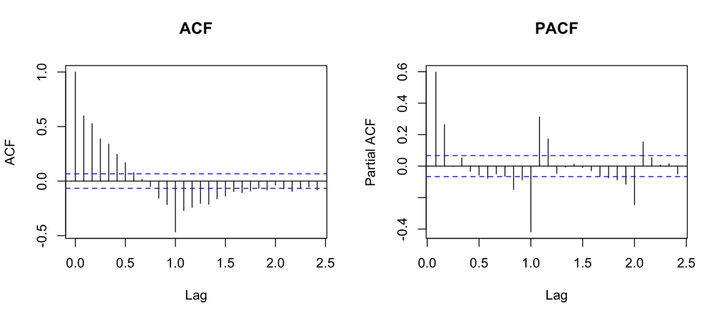

Figure 3.3: ACF and PACF of temperature anomalies time series after applying seasonal differencing with lag 12.

In the ACF plot we observe a cut-off after lag one and in the PACF a cut-off after lag two. So we chose to take the parameters $P=2$ and $Q = 1$. Therefore we now have four possibilities to parametrize our SARIMA$(p,d,q,P,D,Q)$ model:

- SARIMA(2,1,0,2,0,1)
- SARIMA(2,2,0,2,0,1)
- SARIMA(2,1,0,2,1,1)
- SARIMA(2,2,0,2,1,1)

To decide which model to take, we look at their AIC as well as their predictive power. To analyze their predictive power, we take 90% of the dataset as training data, fit the above SARIMA models for the training data and calculate the MSE of a one step forecast. Iteratively in each step we add the next observation of the time series to the training data and again calculate the MSE of a one step forecast for the above models, until we reach the end of the time series. Finally we compute the averages over the MSE’s for each model. Table (3.2) shows the AIC and the described predictive error for each SARIMA model.

Table 3.2: AIC and predictive error for the SARIMA models.

|  | AIC | Predictive Error |
| --- | --- | --- |
| SARIMA(2,1,0,2,0,1) | -1388.450 | 0.0132 |
| SARIMA(2,2,0,2,0,1) | -982.183 | 0.0186 |
| SARIMA(2,1,0,2,1,1) | -1331.419 | 0.0121 |
| SARIMA(2,2,0,2,1,1) | -920.457 | 0.0172 |

The first model (SARIMA(2,1,0,2,0,1)) has the lowest AIC and the second lowest predictive error, while the SARIMA(2,1,0,2,1,1) model has the second lowest AIC and the lowest predictive error. Therefore we proceed with these two models.

Another possibility to chose the parameters of a SARIMA model is using the automated model selection function `auto.arima` from the `forecast` package. It searches the best model according to an information criterion (AIC in our case).

For our time series, `auto.arima` selects a SARIMA(2,1,3,1,0,0) model (with drift). We compare it to our current SARIMA models by AIC and its predictive power.

Table 3.3: AIC and average predictive error for the SARIMA models.

|  | AIC | Predictive Error |
| --- | --- | --- |
| SARIMA(2,1,0,2,0,1) | -1388.450 | 0.0132 |
| SARIMA(2,1,0,2,1,1) | -1331.419 | 0.0121 |
| SARIMA(2,1,3,1,0,0) (selected by auto.arima) | -1436.455 | 0.0129 |

Based on this table it is hard to decide which model to chose, as none dominates the others across both criterions. Hence we decide based on their residual diagnostics. The residuals of a SARIMA model should be white noise and we therefore look at the ACF and PACF plots of the residuals for the three models from Table (3.3).

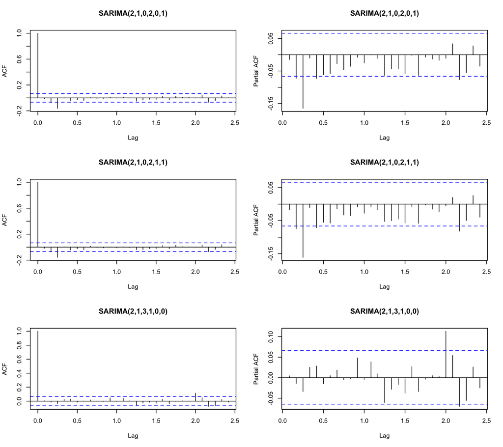

Figure 3.4: ACF and PACF plot of the resodials to compare the SARIMA models.

Based on the residuals, we decide to go for the SARIMA(2,1,3,1,0,0) model, as the PACF plot seems to look slightly better compared to the others. Therefore we proceed with this model.

One more assumption to check is that the residuals should roughly be Gaussian, hence we look at the normal QQ-plot of the residuals in Figure (3.5).

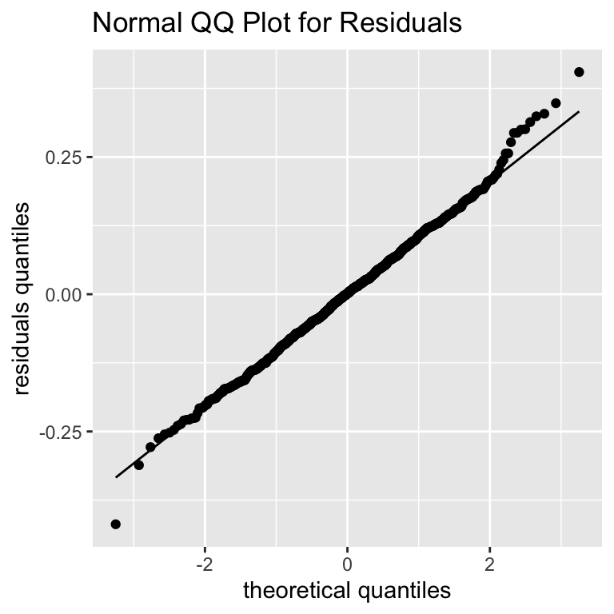

Figure 3.5: Normal QQ-plot for the residuals of the SARIMA(2,1,3,1,0,0) model.

The normal QQ-plot looks fine and therefore we may assume that the residuals of the SARIMA(2,1,3,1,0,0) model are approximately normal. Hence we keep this model to build forecasts in the next section. In Table (3.4) we look at the coefficients of our final model.

Table 3.4: Coefficients of the SARIMA(2,1,3,1,0,0) model.

| ar1 | 0.0687 |
| --- | --- |
| ar2 | 0.6025 |
| ma1 | -0.5763 |
| ma2 | -0.5548 |
| ma3 | 0.1521 |
| sar1 | 0.0079 |
| drift | 0.0012 |

Note that having the non-zero seasonal coefficient sar1 = 0.0079 (since $P$ = 1) means that the prediction for $X_t$ depends linearly on the value of $X_{t-12}$, so we observe a yearly seasonality in our time series (but not a very strong one as the corresponding coefficient is close to 0).

In the next section we will use our final SARIMA model to produce short term temperature forecasts and analyze the form of the trend (e.g. quadratic).

# 4 Global Warming Forecast and Scenarios

As a first forecast visualization, we plot the time series together with a 50 years forecast of our SARIMA(2,1,3,1,0,0) model in Figure (4.1).

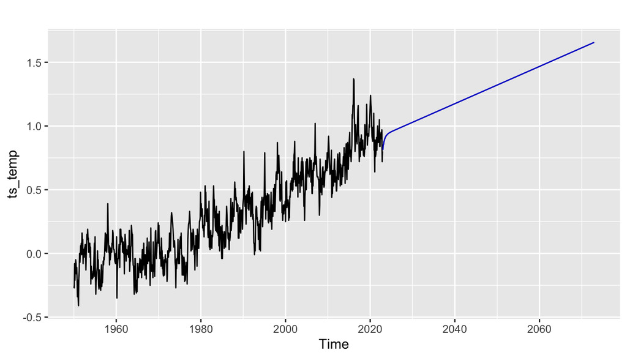

Figure 4.1: Forecast of our temperature anomalies time series with our SARIMA model in blue.

We see that our SARIMA model forecasts an upwards trend for the temperature anomalies in the next 50 years. To test the behaviour of this upwards trend, we use time series regression.

## 4.1 Time Series Regression

In this section we use a generalized least squares (gls) model
$$Y = X\beta + \epsilon, \quad \epsilon \sim \mathcal{N}(0, \sigma^2 \Sigma),$$
where $\Sigma$ will allow for a dependency structure between observations (the observations of our temperature anomalies time series are obviously not independent) to test whether we a linear, a quadratic or an exponential trend in our temperature anomalies is most compatible with the data. To estimate the dependency structure $\Sigma$ we employ an ARMA model for the residuals of a linear model with the temperature anomalies as response. The predictors of this linear model are `month` and `time`, as well as quadratic and exponential dependencies on `time`. The reason why we only use an ARMA model for the residuals (instead of a full SARIMA model) is that by fitting a linear model for the temperature anomalies we hope to remove the trend, and we remove the seasonality by having `month` as predictor. Therefore, after visually verifying the residuals of the linear model, we may assume that our time series of the residuals is stationary.

So in Figure (4.2) we look at the time series of the residuals and its ACF and PACF to determine the parameters of the ARMA model.

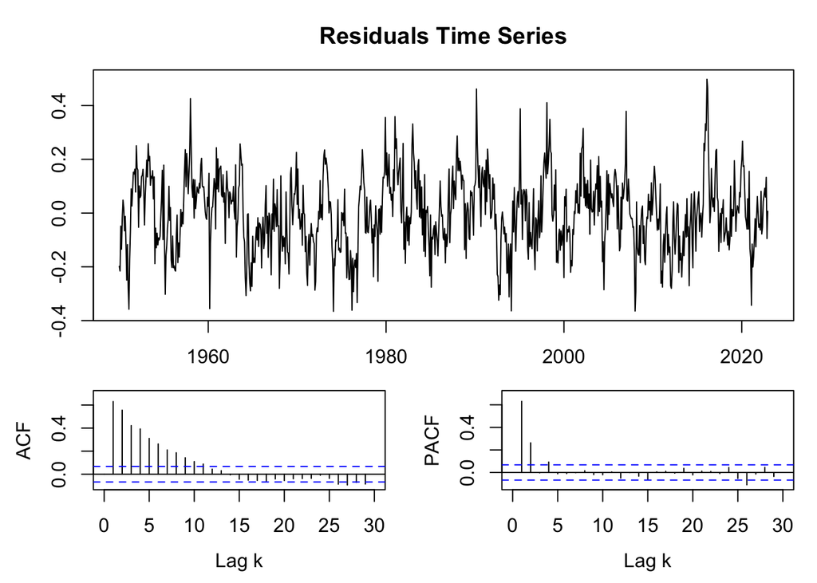

Figure 4.2: Time series of the residuals corresponding to the linear model with the temperature anomalies as response and time, month, a quadratic and an exponential dependency on time as predictors.

First we note that, as expected, our time series looks more or less stationary and there is no clear sign of seasonality, which justifies an ARMA model. Furthermore, by looking at the ACF and PACF plots, we decide to go for an AR(2) model (according to Table (3.1)).

To estimate the dependency structure $\Sigma$ for our gls model we use the `corARMA` function from the `nlme` package. This function creates a dependency structure $\Sigma$ of the time series based on an AR(2) model. The predictors in our gls model are `time` and the factor variable `month`. Furthermore we add an exponential dependency on time in our model and perform an anova type two test to test whether we have an exponential dependency on time or not.

Table 4.1: Type two anova test to test for our generalized least squares model including an exponential dependence on time.

|  | Df | Chisq | Pr(>Chisq) |
| --- | --- | --- | --- |
| time | 1 | 21.1162 | 0.0000 |
| I(exp(time)) | 1 | 0.0141 | 0.9056 |
| month | 11 | 19.9730 | 0.0457 |

We see that the anova Table (4.1) suggests that there is no exponential dependency on time and therefore we refute the hypothesis of an exponential trend. Furthermore, the table suggests that a linear dependence on time seems important.

In Figure (3.1) we saw that a quadratic trend may be plausible for our time series. Therefore we again fit the same gls model, but now include a quadratic dependence on time instead of an exponential dependence. After that we look at the type two anova table as before.

Table 4.2: Type two anova test to test for our generalized least squares model including a quadratic dependence on time.

|  | Df | Chisq | Pr(>Chisq) |
| --- | --- | --- | --- |
| time | 1 | 1.7624 | 0.1843 |
| I(time^2) | 1 | 24.4642 | 0.0000 |
| month | 11 | 28.2488 | 0.0030 |

According to the anova Table (4.2), a quadratic dependency on time is significant.

We therefore conclude that a quadratic dependence on time might be a plausible scenario for the future development of the temperature anomalies, if we do not change our behavior.

# 5 Conclusion

In this report, we used a SARIMA model for a time series containing temperature anomalies from 1950 to 2022. This model allowed us to produce forecasts for the temperature development in the future. We detected a light seasonal effect in the temperature anomalies that can possibly be explained with the fact that most of the earth’s landmass is in the northern hemisphere and hence anomalies in the summer behave differently than anomalies in the winter.

Furthermore, by using time series regression, we were able to refute the hypothesis of an exponential trend for the temperature development and suggested that a quadratic trend might be a more plausible scenario. However, these forecasts should be taken with caution as it is extremely difficult to predict the form of the future global warming because it strongly depends on factors like political policies or natural feedback mechanisms.